# Two-Sample Means (Independent) - Week 2, Lecture 1

Author

Dr. Seals

```r
library(tidyverse)
library(gsheet)
```

**A large credit union awards quarterly bonuses to its employees. To ensure fairness across departments, data on the bonuses are regularly reviewed for equality. Consider the data in the following Google Sheet, which includes the bonus percentage for each employee in two departments.**

```r
data <- as_tibble(gsheet2tbl("https://docs.google.com/spreadsheets/d/1q0Ouhr6hGBDp-5oyQuYGcsWTLrsayywVHJS7o17Sm6Y/edit?usp=sharing"))
```

#### 1. Summarize the data. Provide appropriate summary statistics for the study population.

```r
data %>%
  group_by(Department)  %>%
  summarise(mean = mean(Bonus),
            sd = sd(Bonus),
            median = median(Bonus),
            iqr = IQR(Bonus))
```

```
# A tibble: 2 × 5
  Department  mean    sd median   iqr
  <chr>      <dbl> <dbl>  <dbl> <dbl>
1 Credit      9.68  1.00   9.4  0.925
2 Mortgage    8.53  1.19   8.55 1.42
```

#### 2. Construct the 99% confidence interval for the difference in bonuses for the two departments.

```r
t.test(Bonus ~ Department, data = data, conf.level = 0.99)
```

```
    Welch Two Sample t-test

data:  Bonus by Department
t = 3.9013, df = 43.587, p-value = 0.000327
alternative hypothesis: true difference in means between group Credit and group Mortgage is not equal to 0
99 percent confidence interval:
 0.3560411 1.9439589
sample estimates:
  mean in group Credit mean in group Mortgage
              9.683333               8.533333
```

The 99% CI for $\mu_{\text{C}}-\mu_{\text{M}}$ is (0.36, 1.94).

#### 3. Use the appropriate hypothesis test to determine if the two departments are given different bonus amounts. Test at the α=0.01 level.

```r
t.test(Bonus ~ Department, data = data)
```

```
    Welch Two Sample t-test

data:  Bonus by Department
t = 3.9013, df = 43.587, p-value = 0.000327
alternative hypothesis: true difference in means between group Credit and group Mortgage is not equal to 0
95 percent confidence interval:
 0.5557583 1.7442417
sample estimates:
  mean in group Credit mean in group Mortgage
              9.683333               8.533333
```

**Hypotheses**

- $H_0: \ \mu_{\text{C}} = \mu_{\text{M}}$
- $H_1: \ \mu_{\text{C}} \ne \mu_{\text{M}}$

**Test Statistic**

- $t_0 = 3.901$

*p*-Value

- $p < 0.001$

**Conclusion/Interpretation**

- Reject $H_0$ at the $\alpha=0.01$ level. There is sufficient evidence to suggest that there is a difference in the bonus percentage when comparing the credit and mortgage departments.

#### 4. (Challenge!) Construct a graph that will help you explain your findings to management.

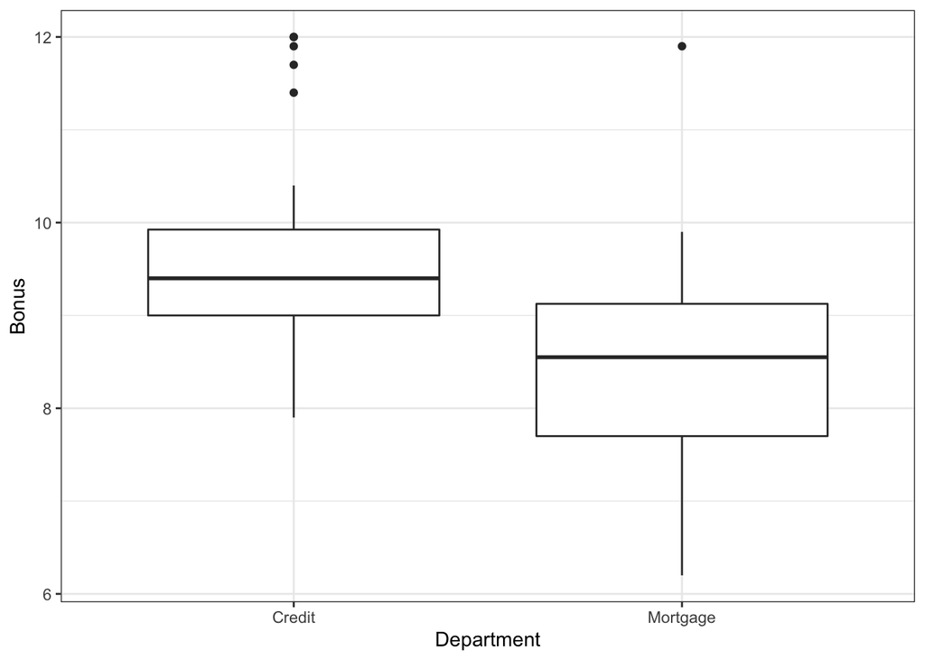

```r
data %>%
  ggplot(aes(y = Bonus, x = Department)) +
  geom_boxplot() +
  theme_bw()
```

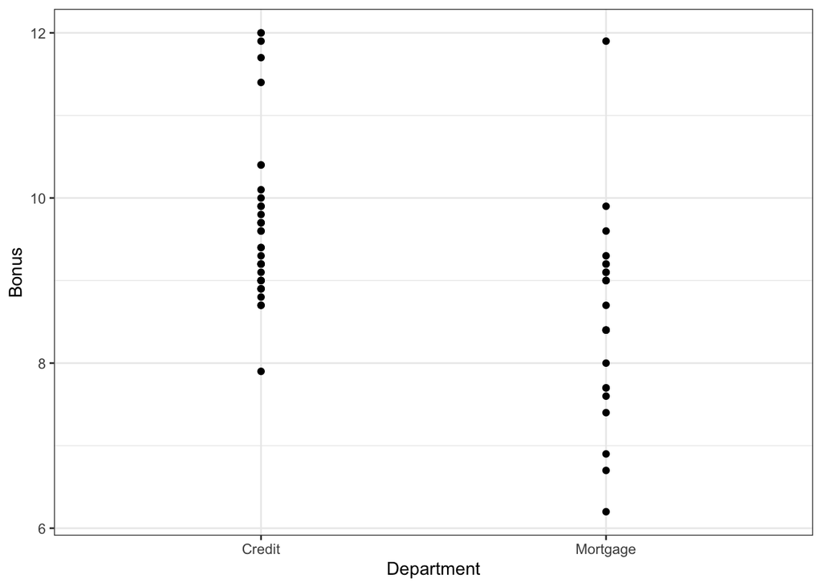

```r
data %>%
  ggplot(aes(y = Bonus, x = Department)) +
  geom_point() +
  theme_bw()
```

#### 5. Write a brief paragraph explaining your findings to management. Are there any actions that should be considered as a result of your analysis?

It is clear that the credit department ($\bar{x}=9.68$) receives, on average, a larger bonus than the mortgage department ($\bar{x}=8.53$). The vast majority of the credit department receives a higher bonus than either the average or median bonus of the mortgage department. Employees may become disgruntled at the inequity between the two departments. Management should consider reevaluation of the bonus policy to be equitable across all departments.